# Replacing t-tests with Linear Mixed Effects Models

Dale Barr

# Stroop data

In the Stroop task (Stroop, 1937), participants see a sequence of words (e.g., “red”) printed in different colours. The participant’s task is simply to say aloud what colour each word is printed in. For example, if a participant were to see the word “horse” printed in green, they are to respond by saying “green”, not “horse.” In effect, participants can completely ignore the words during the task since they only have to name the colours.

Each word appears one by one in a random order, and the participant’s response time is measured: for instance, the time it takes from seeing the green word “horse” until responding “green”.

In the classic version of the task, the words that participants see are actually colour names; for example, the words blue, purple, brown, red, or green. On some trials, the colour that a word is printed in matches the actual word (congruent trial, e.g., the word “red” printed in red). On others, they are mismatched (incongruent trial, e.g., the word “red” printed in green or blue). As you might imagine, participants are slower (and less accurate) to name the printed colour on incongruent than on congruent trials. This difference in response time is known as “the Stroop effect” and is generally thought to indicate the automatic and obligatory nature of reading processes.

## Your task

Imagine that you have run a study testing the hypothesis that native English speakers will show a larger Stroop effect than people who speak English fluently, but as a second language. You will be analyzing simulated data from such a (hypothetical) study.

You have a separate file `stroop2.csv` with the results of the Stroop task. Each row is one trial, with that participant’s ID (`subj_id`), the word (`word`), the colour of the ink that the word was written in (`ink_colour`), the response that the participant gave (`response`), and the reaction time for the response (`rt`).

Each participant is shown a set of congruent trials, where the word and the ink colour matched, and a set of incongruent trials, where the word and the ink colour did not match. The response is correct if it matches the ink colour.

Perform your analysis in an R Markdown file. Make sure you include the following steps:

1. Prepare the data for analysis, removing any trials with inaccurate responses.
2. Make an informative plot of the cell means.
3. Analyze the data using a linear-mixed effects model, with DV `rt` and IVs `native_speaker` and congruency (whether the ink colour matches the word). Use model comparison to test all main effects and interactions.

## Load packages and import the data

```r
library("lme4")
library("tidyverse")

demog <- read_csv("demographics2.csv", col_types = "ic")

stroop <- read_csv("stroop2.csv", col_types = "idccc")

demog
```

```
## # A tibble: 96 x 2
##    subj_id native_speaker
##      <int> <chr>
##  1       1 no
##  2       2 yes
##  3       3 no
##  4       4 no
##  5       5 no
##  6       6 no
##  7       7 yes
##  8       8 yes
##  9       9 yes
## 10      10 yes
## # … with 86 more rows
```

```r
stroop
```

```
## # A tibble: 3,072 x 5
##    subj_id    rt ink_colour response word
##      <int> <dbl> <chr>      <chr>    <chr>
##  1       1  761. pink       pink     yellow
##  2       1  763. pink       pink     green
##  3       1  568. yellow     yellow   purple
##  4       1  641. green      green    red
##  5       1  665. orange     orange   pink
##  6       1  604. purple     purple   green
##  7       1  774. red        red      yellow
##  8       1  650. blue       blue     pink
##  9       1  707. brown      brown    blue
## 10       1  640. orange     pink     pink
## # … with 3,062 more rows
```

## Prepare the data

```r
joined <- demog %>%
  filter(!is.na(native_speaker)) %>%
  inner_join(stroop, "subj_id") %>%
  mutate(congruency = if_else(ink_colour == word, "congruent", "incongruent")) %>%
  filter(response == ink_colour)

joined
```

```
## # A tibble: 2,852 x 7
##    subj_id native_speaker    rt ink_colour response word   congruency
##      <int> <chr>          <dbl> <chr>      <chr>    <chr>  <chr>
##  1       1 no              761. pink       pink     yellow incongruent
##  2       1 no              763. pink       pink     green  incongruent
##  3       1 no              568. yellow     yellow   purple incongruent
##  4       1 no              641. green      green    red    incongruent
##  5       1 no              665. orange     orange   pink   incongruent
##  6       1 no              604. purple     purple   green  incongruent
##  7       1 no              774. red        red      yellow incongruent
##  8       1 no              650. blue       blue     pink   incongruent
##  9       1 no              707. brown      brown    blue   incongruent
## 10       1 no              506. purple     purple   pink   incongruent
## # … with 2,842 more rows
```

## Visualize

We will make a factorial plot of the cell means.

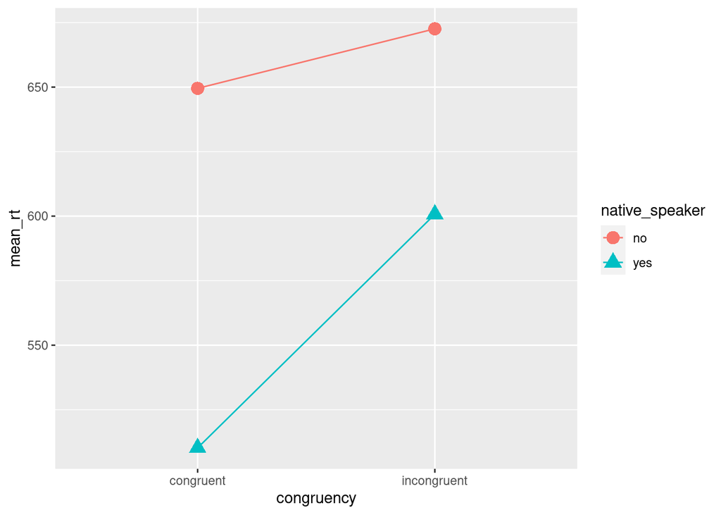

```r
cell_means <- joined %>%
  group_by(native_speaker, congruency) %>%
  summarise(mean_rt = mean(rt, na.rm = TRUE), .groups = "drop")

ggplot(cell_means, aes(congruency, mean_rt, colour = native_speaker)) +
  geom_point(aes(shape = native_speaker), size = 4) +
  geom_line(aes(group = native_speaker))
```

## Perform the analysis

We need deviation-coded predictors.

```r
dev_coded <- joined %>%
  mutate(NS = if_else(native_speaker == "yes", .5, -.5),
         C = if_else(congruency == "incongruent", .5, -.5))

## double-check that we did it correctly
distinct(dev_coded, native_speaker, congruency, NS, C)
```

```
## # A tibble: 4 x 4
##   native_speaker congruency     NS     C
##   <chr>          <chr>       <dbl> <dbl>
## 1 no             incongruent  -0.5   0.5
## 2 no             congruent    -0.5  -0.5
## 3 yes            congruent     0.5  -0.5
## 4 yes            incongruent   0.5   0.5
```

What random effects should be included?

```r
count(dev_coded, subj_id, native_speaker, congruency)
```

```
## # A tibble: 184 x 4
##    subj_id native_speaker congruency      n
##      <int> <chr>          <chr>       <int>
##  1       1 no             congruent      16
##  2       1 no             incongruent    15
##  3       2 yes            congruent      16
##  4       2 yes            incongruent    15
##  5       3 no             congruent      16
##  6       3 no             incongruent    15
##  7       4 no             congruent      16
##  8       4 no             incongruent    15
##  9       5 no             congruent      16
## 10       5 no             incongruent    15
## # … with 174 more rows
```

Native speaker: between subjects (no slope) Congruency: within subjects, multiple observations per level (need random slope)

Now do the analysis.

```r
mod <- lmer(rt ~ NS * C + (C | subj_id), dev_coded, REML = FALSE)

summary(mod)
```

```
## Linear mixed model fit by maximum likelihood  ['lmerMod']
## Formula: rt ~ NS * C + (C | subj_id)
##    Data: dev_coded
##
##      AIC      BIC   logLik deviance df.resid
##  33217.3  33264.9 -16600.6  33201.3     2844
##
## Scaled residuals:
##     Min      1Q  Median      3Q     Max
## -3.7520 -0.6600 -0.0107  0.6765  3.3250
##
## Random effects:
##  Groups   Name        Variance Std.Dev. Corr
##  subj_id  (Intercept) 1238     35.19
##           C           1013     31.83    0.90
##  Residual             6186     78.65
## Number of obs: 2852, groups:  subj_id, 92
##
## Fixed effects:
##             Estimate Std. Error t value
## (Intercept)  608.264      3.953 153.856
## NS          -105.579      7.907 -13.353
## C             56.803      4.438  12.798
## NS:C          67.443      8.877   7.598
##
## Correlation of Fixed Effects:
##      (Intr) NS    C
## NS   0.000
## C    0.634  0.000
## NS:C 0.000  0.634 0.000
```

OK, let’s do model comparison.

```r
mod_NS <- update(mod, . ~ . -NS)
mod_C <- update(mod, . ~ . -C)
mod_NSC <- update(mod, . ~ . -NS:C)

anova(mod, mod_NS) # main effect of native speaker
```

```
## Data: dev_coded
## Models:
## mod_NS: rt ~ C + (C | subj_id) + NS:C
## mod: rt ~ NS * C + (C | subj_id)
##        npar   AIC   BIC logLik deviance Chisq Df Pr(>Chisq)
## mod_NS    7 33314 33356 -16650    33300
## mod       8 33217 33265 -16601    33201 99.15  1  < 2.2e-16 ***
## ---
## Signif. codes:  0 '***' 0.001 '**' 0.01 '*' 0.05 '.' 0.1 ' ' 1
```

```r
anova(mod, mod_C) # main effect of congruency
```

```
## Data: dev_coded
## Models:
## mod_C: rt ~ NS + (C | subj_id) + NS:C
## mod: rt ~ NS * C + (C | subj_id)
##       npar   AIC   BIC logLik deviance  Chisq Df Pr(>Chisq)
## mod_C    7 33309 33351 -16648    33295
## mod      8 33217 33265 -16601    33201 94.075  1  < 2.2e-16 ***
## ---
## Signif. codes:  0 '***' 0.001 '**' 0.01 '*' 0.05 '.' 0.1 ' ' 1
```

```r
anova(mod, mod_NSC) # native speaker by congruency interaction
```

```
## Data: dev_coded
## Models:
## mod_NSC: rt ~ NS + C + (C | subj_id)
## mod: rt ~ NS * C + (C | subj_id)
##         npar   AIC   BIC logLik deviance  Chisq Df Pr(>Chisq)
## mod_NSC    7 33260 33302 -16623    33246
## mod        8 33217 33265 -16601    33201 44.804  1  2.178e-11 ***
## ---
## Signif. codes:  0 '***' 0.001 '**' 0.01 '*' 0.05 '.' 0.1 ' ' 1
```